# R Notebook

hypothesis tests

```r
library(tidyverse)
library(janitor)
library(infer)

books <- read_csv("data_1/books.csv")

books_tidy <- books %>%
  clean_names() %>%
  filter(!is.na(average_rating)) %>%
  rename(num_pages = number_num_pages) %>%
  glimpse()
```

[figure not shown]

the 2020 average rating is different from 2016

```r
observed_stats <- mean(books$average_rating, na.rm = TRUE)
#average rating is 3.93756
```

#2016 is 3.93 #2020 is 3.937568 set up two competing hypothesis

our 2 hypothesis must be - mutually exclusive - exhaustive (cover every possible outcomes)

$$H_0:μ_{average\ rating} = 3.93$$

$$H_0:μ_{average\ rating} \neq 3.93$$
greek letter used to represent population parameters
$$\mu = population \ mean \\\\\\\\\\
\pi = population\ proportion$$
latin letter for estimates #2016 is 3.93 #2020 is 3.937568 is this difference *significant*

##steps of hypothesis test >step1

*before* we look at the data decide on our *significant level*(alpha level) : set a threshold for what counts as significant, set the error rate, it will dictate how often we wrongly declare significance - so with a of 0.05, we can expect to be wrongly reject HO 1 time in 20

by convention, at least very often, the most common alpha level is *0.05*

> step2

calculate the statistic in this case it’s the mean

> step3

create the sampling distribution we’ll do this by bootstrapping *very important* when we create the sampling distribution we *assume that it is true*

> step4

compare our calculated statistic with the sampling distribution

if the calculated stat is far enough into the the tail of our normal distribution , we call it significant p_value

> step5

if the p_value is < alpha we *reject* H0 if the p_value is NOT < alpha we *do not reject* H0 didn’t say we *accept* the H0

if the p_value is < alpha we *reject* H0 find evidence in support of our H1 if the p_value is NOT < alpha we *do not reject* H0 didn’t say we *accept* the H0 failed to find evidence in support of our H1

hypothesis with infer

```r
null_distribution<- books_tidy %>%
  specify(response = average_rating) %>%
  hypothesise(null = 'point', mu = 3.93) %>%
  generate(reps = 1000, type = "bootstrap") %>%
  calculate(stat = "mean")

null_distribution
```

```
Response: average_rating (numeric)
Null Hypothesis: point
```

| replicate | stat |
| --- | --- |
| 1 | 3.933643 |
| 2 | 3.926371 |
| 3 | 3.929390 |
| 4 | 3.931612 |
| 5 | 3.933367 |
| 6 | 3.925417 |
| 7 | 3.934261 |
| 8 | 3.926256 |
| 9 | 3.929101 |
| 10 | 3.922909 |

[output cut: 990 more lines]

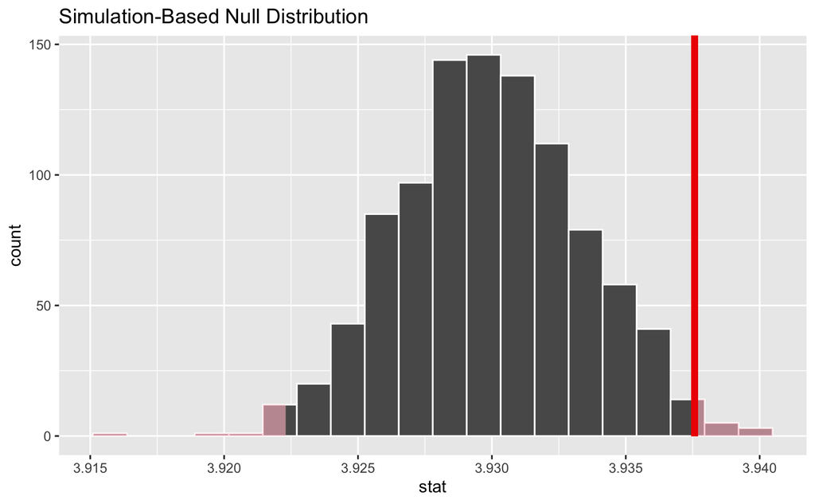

```r
null_distribution %>%
  visualise(bins = 20) +
  shade_p_value(obs_stat = observed_stats, direction = 'both')
```

```r
observed_stats
```

```
[1] 3.937568
```

can do one tail test eg: mu > 3.93

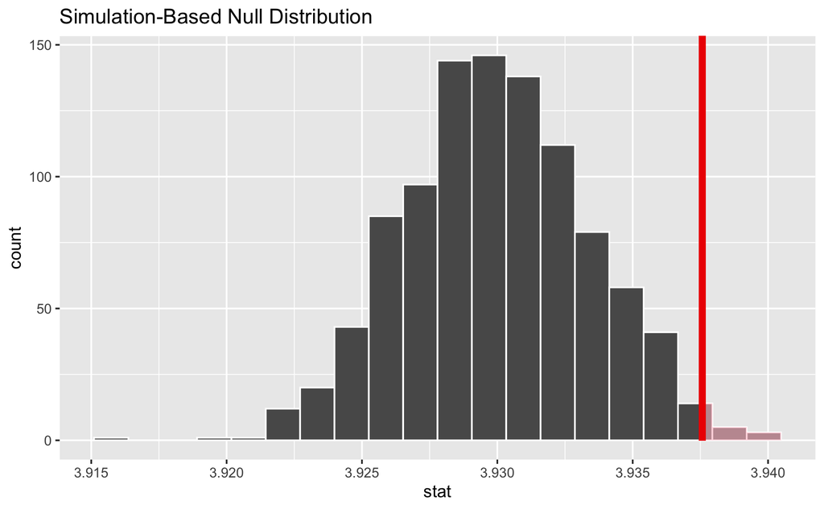

```r
null_distribution %>%
  visualise(bins = 20) +
  shade_p_value(obs_stat = observed_stats, direction = 'greater')
```

```r
observed_stats
```

```
[1] 3.937568
```

[output not shown]

what does p_value means? > how likely is it to see a result as extreme as your observed result, if the null hypothesus is true

(extreme means p is less than alpha=0.05)

> is the null was true, how weird would this data be

*don’t say P_VALUE is the probability that H0 is correct*

our observed stat of 3.937.. is significantly different from our NULL stat of 3.93 at alpha level of 0.05, we therefore find evidence in support of out alternative hypothesis

```r
books_tidy %>%
  group_by(text_reviews_count) %>%
  summarise(prop= n()/nrow(books_tidy)) %>%
  filter(text_reviews_count == 0)
```

| text_reviews_count | prop |
| --- | --- |
| 0 | 0.06455132 |

> step1

> step2

$$\frac{number\ of\ books\ with\ no\ reviews\ }{total\ books }$$

> step3

create the sampling distribution we’ll do this by bootstrapping *very important* when we create the sampling distribution we *assume that it is true*

> step4

compare our calculated statistic with the sampling distribution

if the calculated stat is far enough into the the tail of our normal distribution , we call it significant p_value

> step5

if the p_value is < alpha we *reject* H0 if the p_value is NOT < alpha we *do not reject* H0 didn’t say we *accept* the H0

if the p_value is < alpha we *reject* H0 find evidence in support of our H1 if the p_value is NOT < alpha we *do not reject* H0 didn’t say we *accept* the H0 failed to find evidence in support of our H1

```r
mean(book_tidy_prop$has_reviews)
```

```
[1] 0.9354487
```

point==point estimate just one value type = draw just simple draw out of a bag

```r
null_distribution_reviews
```

```
Response: has_reviews (factor)
Null Hypothesis: point
```

| replicate | stat |
| --- | --- |
| 1 | 0.07173379 |
| 2 | 0.06973361 |
| 3 | 0.06864260 |
| 4 | 0.06727884 |
| 5 | 0.07037003 |
| 6 | 0.06336940 |
| 7 | 0.07018820 |
| 8 | 0.07318847 |
| 9 | 0.07055187 |
| 10 | 0.07073370 |

[output cut: 990 more lines]

[figure not shown]

```r
observed_stats_prop <- book_tidy_prop %>%
  specify(response = has_reviews, success = 'FALSE') %>%
  calculate(stat = "prop")

observed_stats_prop
```

```
Response: has_reviews (factor)
```

| stat |
| --- |
| 0.06455132 |

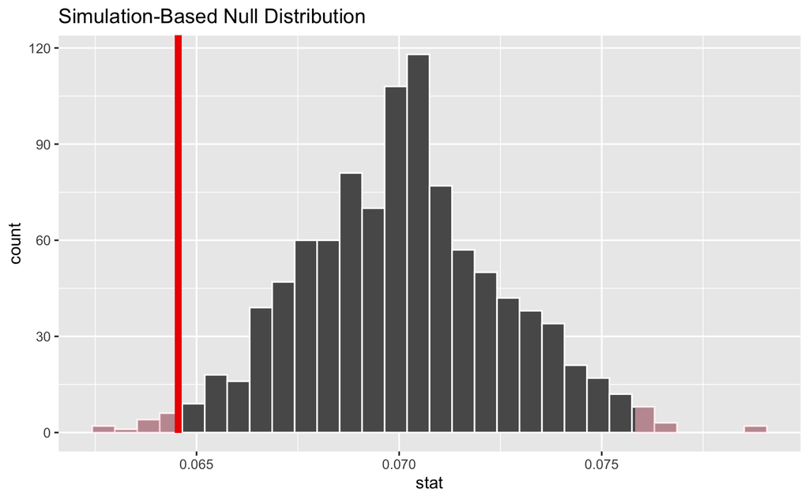

```r
null_distribution_reviews %>%
  visualise(bins = 30) +
  shade_p_value(obs_stat = observed_stats_prop$stat, direction = 'both')
```

```r
NA
```

```r
p_value_prop <- null_distribution_reviews %>%
  get_p_value(obs_stat = observed_stats_prop, direction = "both")

p_value_prop
```

| p_value |
| --- |
| 0.024 |

p is less than 0.05 reject H0 we reject h0 and our prop is different

two sample -independent -paired

```r
nice <- read_csv('data_3/nice.csv')
algarve <- read_csv('data_3/algarve.csv')
corfu <- read_csv('data_3/corfu.csv')
florence <- read_csv('data_3/florence.csv')
```

independent means the observations are not assisated with each other

N0: the lets price are the same N1: the lets price are different

N0: mu(mean let price nice) = mu(mean let price algarve) N0: mu(mean let price nice) != mu(mean let price algarve)

| location | ...1 | price |
| --- | --- | --- |
| nice | 1 | 1594 |
| nice | 2 | 1537 |
| nice | 3 | 1565 |
| nice | 4 | 1477 |
| nice | 5 | 2072 |
| nice | 6 | 1608 |
| nice | 7 | 1482 |
| nice | 8 | 2249 |
| nice | 9 | 2238 |
| nice | 10 | 1761 |

[output cut: 90 more lines]

[figure not shown]

y ~ x in specify same as response = price explanatory = location

```r
null_distribution <- apart_price %>%
  specify(price ~ location) %>%
  hypothesise(null = 'independence') %>%
  generate(rep = 1000, type = 'permute') %>%
  calculate(stat = "diff in means", order = c('algarve', 'nice'))

null_distribution
```

```
Response: price (numeric)
Explanatory: location (factor)
Null Hypothesis: independence
```

| replicate | stat |
| --- | --- |
| 1 | -39.76666667 |
| 2 | -60.26666667 |
| 3 | 13.27500000 |
| 4 | -77.47500000 |
| 5 | -107.89166667 |
| 6 | 35.31666667 |
| 7 | 162.85833333 |
| 8 | 41.31666667 |
| 9 | -67.64166667 |
| 10 | 1.27500000 |

[output cut: 990 more lines]

```r
observed_stats
```

```
Response: price (numeric)
Explanatory: location (factor)
```

| stat |
| --- |
| 251.4 |

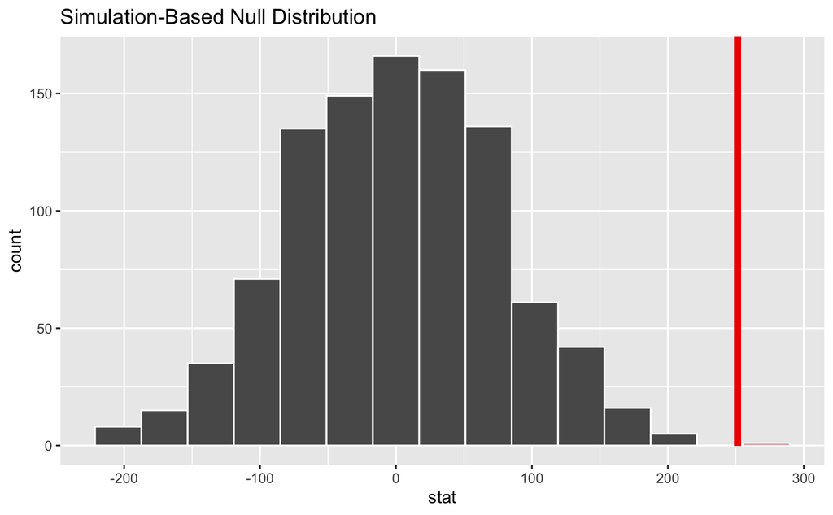

```r
null_distribution %>%
  visualise()+
  shade_p_value(obs_stat = observed_stats, direction = "right")
```

[output not shown]

We have two more datasets for similar apartment lets in Corfu and Florence. Frame and perform an independent two-sample test to answer the following question: ‘On average, is the price of 2-bedroom, 14-day holiday apartment lets in Florence significantly lower than that of comparable lets in Corfu?’ Choose α and frame your hypotheses before you see the data *α* = 0.05,

$$NO: \mu_{corfu\ price} = \mu_{florence\ price}\\
N1: \mu_{corfu\ price} \neq \mu_{florence\ price}$$

You will need to format your data in a combined, tidy dataset prior to performing the test

```r
apart_price_cf <- bind_rows(corfu = corfu,
                        florence = florence,
                         .id = 'location')
```

```r
null_distribution <- apart_price_cf %>%
  specify(price ~ location) %>%
  hypothesise(null = 'independence') %>%
  generate(rep = 1000, type = 'permute') %>%
  calculate(stat = "diff in means", order = c('corfu', 'florence'))

null_distribution
```

```
Response: price (numeric)
Explanatory: location (factor)
Null Hypothesis: independence
```

| replicate | stat |
| --- | --- |
| 1 | 1.07032967 |
| 2 | 1.72307692 |
| 3 | 66.46373626 |
| 4 | 95.36263736 |
| 5 | -89.89890110 |
| 6 | 112.63076923 |
| 7 | 28.42637363 |
| 8 | -64.61978022 |
| 9 | 48.86923077 |
| 10 | 30.14725275 |

[output cut: 990 more lines]

```r
observed_stats <- apart_price_cf %>%
  specify(price ~ location) %>%
  calculate(stat = 'diff in means', order = c('corfu', 'florence'))

observed_stats
```

```
Response: price (numeric)
Explanatory: location (factor)
```

| stat |
| --- |
| -824.1802 |

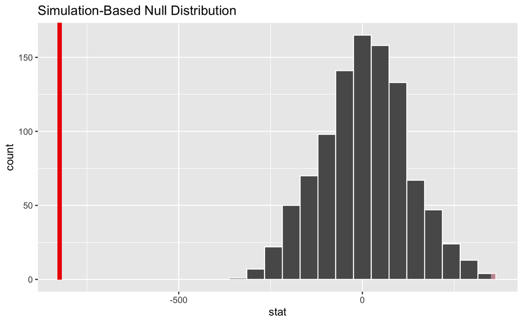

```r
null_distribution %>%
  visualise()+
  shade_p_value(obs_stat = observed_stats, direction = "both")
```

```r
p_value <- null_distribution %>%
  get_p_value(obs_stat = observed_stats, direction = "both")
p_value
```

| p_value |
| --- |
| 0 |

```r
textbook <- read_csv('data_3/ucla_textbooks_f18.csv')
```

$$N0: \mu_{campus} = \mu_{amazon}\\
N1: \mu_{campus} > \mu_{amazon}$$

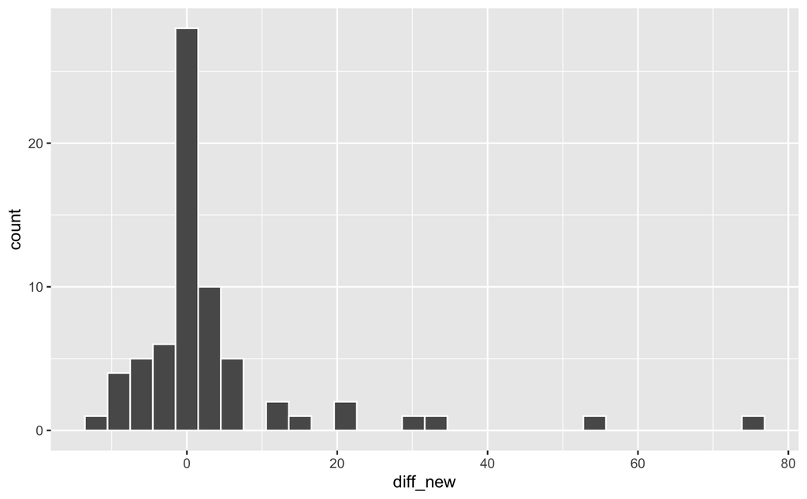

```r
books_diff <- textbook %>%
  mutate(diff_new = bookstore_new - amazon_new) %>%
  filter(!is.na(diff_new))

books_diff %>%
  ggplot(aes(x = diff_new)) +
  geom_histogram(col = 'white')
```

## Infer procedure

1. Calculate the *observed* statistic
   1. Create *“flag”* column if necessary
   2. Specify the *response* variable
   3. Calculate the required *stat* e.g. prop / mean
2. Generate the *null distribution*
   1. Specify the *response*
   2. Indicate the *hypothesis* What type of hypothesis (e.g. point) Specify the proportion p (the observed stat)
   3. Generate the *null distribution*
   4. Calculate the *stat* of interest
3. *Visualize* the resut Shade p-value region
4. Extract the *p-value*

```r
null_distribution
```

```
Response: diff_new (numeric)
Null Hypothesis: point
```

| replicate | stat |
| --- | --- |
| 1 | -0.566617647 |
| 2 | 0.967647059 |
| 3 | -0.157205882 |
| 4 | -1.706323529 |
| 5 | -0.738382353 |
| 6 | 0.122205882 |
| 7 | 1.632941176 |
| 8 | -0.870882353 |
| 9 | 0.800588235 |
| 10 | 0.380735294 |

[output cut: 990 more lines]

```r
observed_stats
```

```
Response: diff_new (numeric)
```

| stat |
| --- |
| 3.583235 |

[figure not shown]

```r
null_distribution %>%
  get_p_value(obs_stat = observed_stats, direction = 'both')
```

| p_value |
| --- |
| 0.038 |

‘On average, are the prices of used course texts lower on Amazon than at the campus bookstore?’

```
N0: diff_in_means = 0
N1: diff_in_mean < 0 (amazon - campus book < 0 )
```

Hints:

It will help to start with a clear definition: diff_used = bookstore_used - amazon_used or diff_used = amazon_used - bookstore_used This will be a one-tailed test, so frame your hypotheses appropriately.

```r
books_diff_used <- textbook %>%
  mutate(diff_used =  amazon_used - bookstore_used) %>%
  filter(!is.na(diff_used))

books_diff_used %>%
  ggplot(aes(x = diff_used)) +
  geom_histogram(col = 'white')
```

[output not shown]

```r
null_distribution <- books_diff_used %>%
  specify(response = diff_used) %>%
  hypothesise(null = 'point', mu = 0 ) %>%
  generate(reps = 1000, type = 'bootstrap') %>%
  calculate(stat = 'mean')

null_distribution
```

```r
observed_stats <- books_diff_used %>%
specify(response = diff_used) %>%
   calculate(stat = 'mean')

observed_stats
```

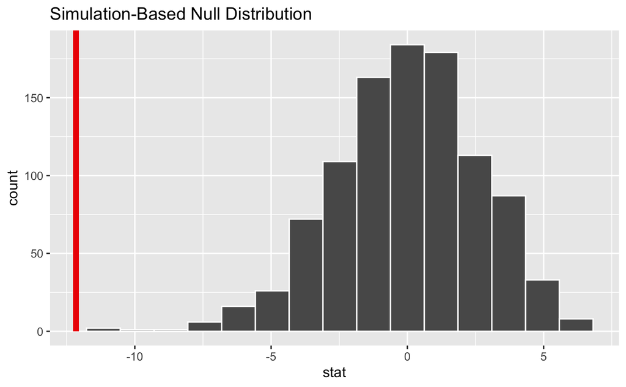

```r
null_distribution %>%
  visualise()+
  shade_p_value(obs_stat = observed_stats, direction = 'less')
```

```r
null_distribution %>%
  get_p_value(obs_stat = observed_stats, direction = 'less')
```

[output not shown]

we reject null, amazon is significantly lower for used textbooks